```python
from IPython.display import HTML

HTML('''<script>
code_show=true;
function code_toggle() {
 if (code_show){
 $('div.input').hide();
 } else {
 $('div.input').show();
 }
 code_show = !code_show
}
$( document ).ready(code_toggle);
</script>
<form action="javascript:code_toggle()"><input type="submit" value="Click here to toggle on/off the raw code."></form>''')
```

```python
import healpy as hp
import pylab as pl
from pylab import cm

cmap = cm.get_cmap('RdYlBu')
cmap.set_under('w')




inputclfile ='/Users/peppe/work/satellite_sims/sigonly/inputcl.fits'
try :
    cl = hp.read_cl(filename=inputclfile)
except IOError:
    cl=hp.anafast(cmbmaps, lmax=lmax)
    hp.write_cl(cl=cl, filename='inputclfile' )
hitmap=hp.read_map('/Users/peppe/work/satellite_sims/madam_hmap.fits', verbose=False)
#hp.mollview(pl.log10( hitmap), min=3.5, max=4, unit='Log (hitcounts)' ,title='', cmap=cmap )
cl = pl.loadtxt('/Users/peppe/work/satellite_sims/Class_planck2015_r0_cl_lensed.dat')
lmax=3*hp.get_nside(hitmap)
l=pl.arange(2, lmax+1)
Nl =lambda w: (pl.pi /180. /60. * w)**2
wp=7.6 # uK arcmin
Nl0= Nl(wp)
```

# Dipole only runs

### Changing the drift time-scale

We run Toast, observe just a dipole map, and inject gain fluctuations with a $5\%$ width **on a time-scale of 1 day**. I smooth the maps to $1^\circ $ so that large scales are emphasized.

**timescale=24 h**

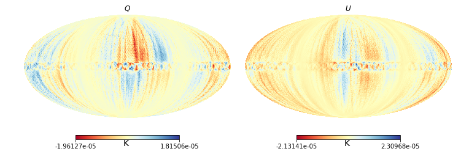

```python
map1  = hp.read_map(field=range(3) ,
                       filename='madam_bmap_001.fits',
                       verbose=False)
fig=pl.figure(figsize=(15,8))
driftmap1=  hp.smoothing(map_in=map1, fwhm=pl.deg2rad(1.), verbose=False  )
#hp.mollview(  driftmap1 [0], unit='K ', title=r'$  T$  ', sub=131 , fig=fig ,cmap=cmap  )
hp.mollview(driftmap1 [1], unit='K ', title=r'$  Q$', sub=132 , fig=fig ,cmap=cmap )
hp.mollview(driftmap1 [2], unit='K ', title=r'$U$', sub=133 , fig=fig ,cmap=cmap )
cl1=hp.anafast( map1 , lmax=lmax)
```

**Figure 1:** We are simply emphasizing the cumulative effect (on a daily scale) of having a mismatch between detA and detB. Notice that a large scale pattern appears on both Q, U maps and the wiggles along the equator

Now, I reduce the drift time-scale to **12 h**.

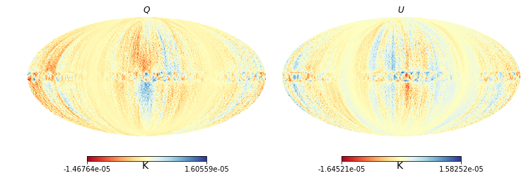

```python
map9  = hp.read_map(field=range(3) ,
                       filename='madam_bmap_009.fits',
                       verbose=False)
cl9=hp.anafast( map9 , lmax=lmax)
fig=pl.figure(figsize=(15,8))
driftmap9=  hp.smoothing(map_in=map9, fwhm=pl.deg2rad(1.), verbose=False )
#hp.mollview(  driftmap2 [0], unit='K ', title=r'$  T$  ', sub=131 , fig=fig ,cmap=cmap  )
hp.mollview(driftmap9 [1], unit='K ', title=r'$  Q$', sub=132 , fig=fig ,cmap=cmap)
hp.mollview(driftmap9 [2], unit='K ', title=r'$U$', sub=133 , fig=fig ,cmap=cmap )
```

Notice that the maps start to become noisier..

We gradually reduce the drift time-scale from 6 h to 1 precession period (i.e. 1.5h ) .

**Time scale= 6 h**

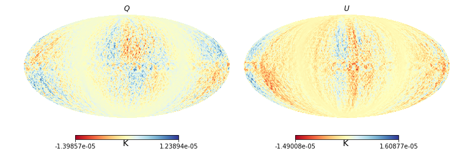

```python
map10  = hp.read_map(field=range(3) ,
                       filename='madam_bmap_010.fits',
                       verbose=False)
fig=pl.figure(figsize=(15,8))
driftmap10=  hp.smoothing(map_in=map10, fwhm=pl.deg2rad(1.), verbose=False )
#hp.mollview(  driftmap2 [0], unit='K ', title=r'$  T$  ', sub=131 , fig=fig ,cmap=cmap  )
hp.mollview(driftmap10 [1], unit='K ', title=r'$  Q$', sub=132 , fig=fig ,cmap=cmap)
hp.mollview(driftmap10 [2], unit='K ', title=r'$U$', sub=133 , fig=fig ,cmap=cmap )
```

**Time-scale =3h**

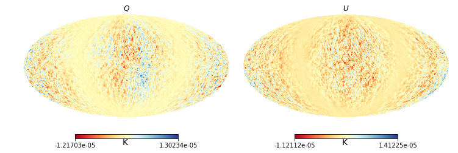

```python
map11  = hp.read_map(field=range(3) ,
                       filename='madam_bmap_011.fits',
                       verbose=False)
fig=pl.figure(figsize=(15,8))
driftmap11=  hp.smoothing(map_in=map11, fwhm=pl.deg2rad(1.), verbose=False )
#hp.mollview(  driftmap2 [0], unit='K ', title=r'$  T$  ', sub=131 , fig=fig ,cmap=cmap  )
hp.mollview(driftmap11 [1], unit='K ', title=r'$  Q$', sub=132 , fig=fig ,cmap=cmap)
hp.mollview(driftmap11 [2], unit='K ', title=r'$U$', sub=133 , fig=fig ,cmap=cmap )
```

**Time-scale=1.5 h**

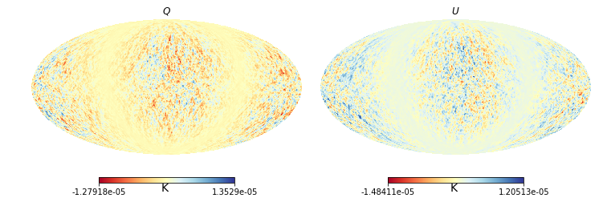

```python
map2  = hp.read_map(field=range(3) ,
                       filename='madam_bmap_002.fits',
                       verbose=False)
cl2=hp.anafast( map2 , lmax=lmax)
fig=pl.figure(figsize=(15,8))
driftmap2=  hp.smoothing(map_in=map2, fwhm=pl.deg2rad(1.), verbose=False )
#hp.mollview(  driftmap2 [0], unit='K ', title=r'$  T$  ', sub=131 , fig=fig ,cmap=cmap  )
hp.mollview(driftmap2 [1], unit='K ', title=r'$  Q$', sub=132 , fig=fig ,cmap=cmap)
hp.mollview(driftmap2 [2], unit='K ', title=r'$U$', sub=133 , fig=fig ,cmap=cmap )
```

If the gain mismatches are on a shorter time-scale any coherence will be lost: the gain fluctuates too fast and looks as noise. Indeed for an even smaller time-scale **10 min** we observe similar structures.

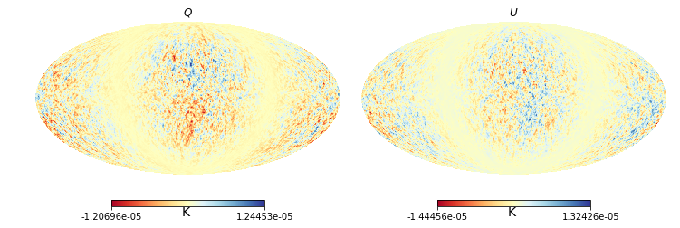

```python
map0  = hp.read_map(field=range(3) ,
                       filename='madam_bmap.fits',
                       verbose=False)
#cldriftdip=hp.anafast(driftmap , lmax=lmax)
fig=pl.figure(figsize=(15,8))
driftmap0=  hp.smoothing(map_in=map0, fwhm=pl.deg2rad(1.) , verbose=False)
#hp.mollview(  driftmap0 [0], unit='K ', title=r'$  T$  ', sub=131 , fig=fig ,cmap=cmap , )
hp.mollview(driftmap0 [1], unit='K ', title=r'$  Q$', sub=132 , fig=fig ,cmap=cmap )
hp.mollview(driftmap0 [2], unit='K ', title=r'$U$', sub=133 , fig=fig ,cmap=cmap )
cl0=hp.anafast( map0 , lmax=lmax)
```

## Reducing gain width

Now let's keep the time-scale to 24 h and reduce the width of the distribution by an order of magnitude ($0.5 \%$ ). We expect a leakage in the Q and U maps about 1 orders of magnitude smaller than the one in Fig.1

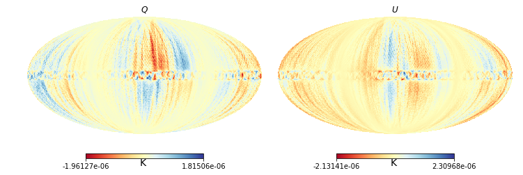

```python
map3  = hp.read_map(field=range(3) ,
                       filename='madam_bmap_003.fits',
                       verbose=False)
fig=pl.figure(figsize=(15,8))
driftmap3=  hp.smoothing(map_in=map3, fwhm=pl.deg2rad(1.), verbose=False )
#hp.mollview(  driftmap1 [0], unit='K ', title=r'$  T$  ', sub=131 , fig=fig ,cmap=cmap  )
hp.mollview(driftmap3 [1], unit='K ', title=r'$  Q$', sub=132 , fig=fig ,cmap=cmap)
hp.mollview(driftmap3 [2], unit='K ', title=r'$U$', sub=133 , fig=fig ,cmap=cmap )
cl3=hp.anafast( map3 , lmax=lmax)
```

We do observe similar stripes as in Fig.1 and more importantly a factor of 10 lower leakage.

Let's check out the power spectra.

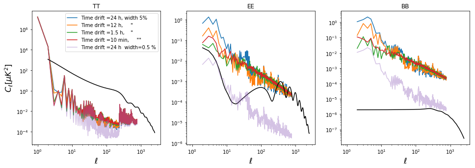

```python
fig=pl.figure(figsize=(16, 5))
dicspectra={0:'TT', 1:'EE', 2:'BB', 3:'TE'}
for i in xrange(3):
    pl.subplot(131 +i )
    pl.title(dicspectra[i])
    pl.loglog(cl1[i,:]*1e12, label = 'Time drift =24 h, width 5% ')
    pl.loglog(cl9[i,:]*1e12, label = 'Time drift =12 h,     " ')
    pl.loglog(cl2[i,:]*1e12, label = 'Time drift =1.5 h,    " ')
    pl.loglog(cl0[i,:]*1e12, label = 'Time drift =10 min,     ""')




    pl.loglog(cl[:,0] ,cl[:,i+1],'k')
    pl.loglog(cl3[i,:]*1e12, alpha=.4, label = 'Time drift =24 h  width=0.5 %')

    if i==0:
        pl.ylabel(r'$C_{\ell} [ \mu K^2 ]$', fontsize=16)
        pl.legend()
    pl.xlabel(r'$ {\ell}  $', fontsize=16)
```

# Dipole + T runs

We now include Temperature fluctuations to the Dipole observations .Similarly to the above

```python
map4  = hp.read_map(field=range(3) ,
                       filename='madam_bmap_004.fits',
                       verbose=False)
fig=pl.figure(figsize=(15,8))
driftmap4=  hp.smoothing(map_in=map4, fwhm=pl.deg2rad(1.),verbose=False  )


cl4=hp.anafast( map4 , lmax=lmax)

map8  = hp.read_map(field=range(3) ,
                       filename='madam_bmap_008.fits',
                       verbose=False)
driftmap8=  hp.smoothing(map_in=map8, fwhm=pl.deg2rad(1.),verbose=False  )

cl8=hp.anafast( map8 , lmax=lmax)
```

### Time-scale 24h , width =5%

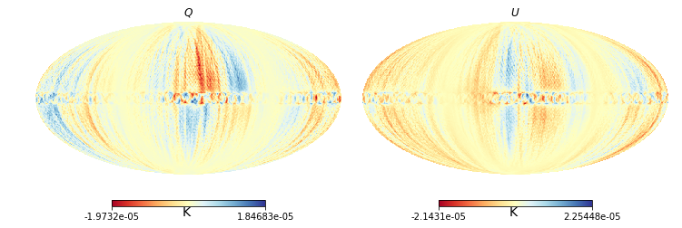

```python
fig=pl.figure(figsize=(15,8))

hp.mollview(driftmap8 [1], unit='K ', title=r'$  Q$', sub=132 , fig=fig ,cmap=cmap)
hp.mollview(driftmap8 [2], unit='K ', title=r'$U$', sub=133 , fig=fig ,cmap=cmap )
```

### Time-scale 24h , width =0.5%

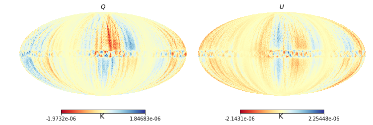

```python
fig=pl.figure(figsize=(15,8))

hp.mollview(driftmap4 [1], unit='K ', title=r'$  Q$', sub=132 , fig=fig ,cmap=cmap)
hp.mollview(driftmap4 [2], unit='K ', title=r'$U$', sub=133 , fig=fig ,cmap=cmap )
```

```python
map5  = hp.read_map(field=range(3) ,
                       filename='madam_bmap_005.fits',
                       verbose=False)

driftmap5=  hp.smoothing(map_in=map5, fwhm=pl.deg2rad(1.),verbose=False )
cl5=hp.anafast( map5 , lmax=lmax)

map7 = hp.read_map(field=range(3) ,
                       filename='madam_bmap_007.fits',
                       verbose=False)
driftmap7=  hp.smoothing(map_in=map7, fwhm=pl.deg2rad(1.),verbose=False )

cl7=hp.anafast( map7 , lmax=lmax)
```

### Time-scale 1.5 h , width =5%

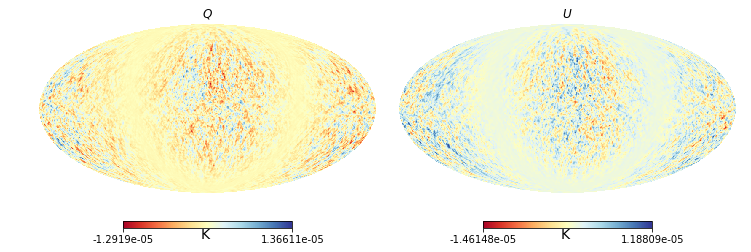

```python
fig=pl.figure(figsize=(15,8))
hp.mollview(driftmap7 [1], unit='K ', title=r'$  Q$', sub=132 , fig=fig ,cmap=cmap)
hp.mollview(driftmap7 [2], unit='K ', title=r'$U$', sub=133 , fig=fig ,cmap=cmap )
```

### Time-scale 1.5 h , width =0.5%

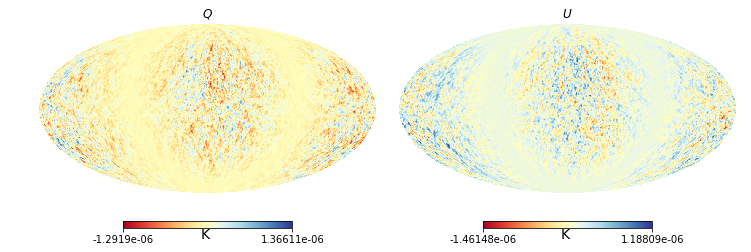

```python
fig=pl.figure(figsize=(15,8))
hp.mollview(driftmap5 [1], unit='K ', title=r'$  Q$', sub=132 , fig=fig ,cmap=cmap)
hp.mollview(driftmap5 [2], unit='K ', title=r'$U$', sub=133 , fig=fig ,cmap=cmap )
```

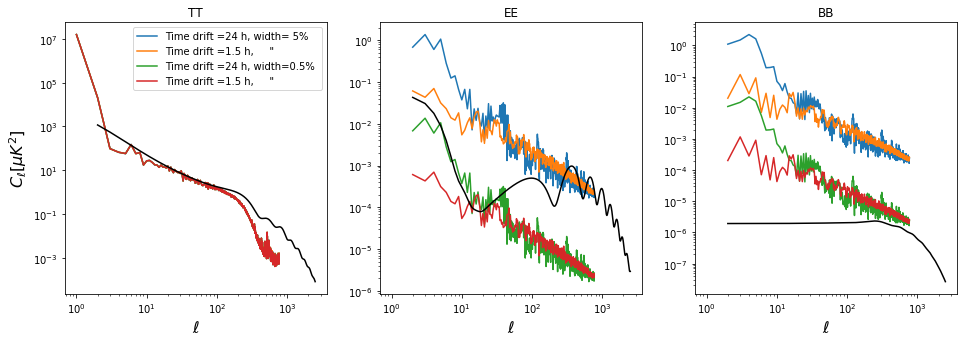

```python
fig=pl.figure(figsize=(16, 5))
dicspectra={0:'TT', 1:'EE', 2:'BB', 3:'TE'}
for i in xrange(3):
    pl.subplot(131 +i )
    pl.title(dicspectra[i])
    pl.loglog(cl8[i,:]*1e12, label = 'Time drift =24 h, width= 5% ')
    pl.loglog(cl7[i,:]*1e12, label = 'Time drift =1.5 h,     " ')
    pl.loglog(cl4[i,:]*1e12, label = 'Time drift =24 h, width=0.5% ')
    pl.loglog(cl5[i,:]*1e12, label = 'Time drift =1.5 h,     " ')
    pl.loglog(cl[:,0] ,cl[:,i+1], 'k')

    if i==0:
        pl.legend()
        pl.ylabel(r'$C_{\ell} [ \mu K^2 ]$', fontsize=16)
    pl.xlabel(r'$ {\ell}  $', fontsize=16)
```